# An Analysis of Building Permits in San Francisco, California

Fall 2024 Data Science Project Created by Akash Balenalli and Noah Kasica

**Contributions:**

A: The dataset for this project was found by Akash because he was interested in analyzing housing data.

B: We both aided in the curation and preprocessing of data.

C: Noah created the pie chart representing NA data, the bar graph depicting permit completion rate by neighborhood, and computed Cramer's V. Akash create the pie chart depicting neighborhoods the dataset is comprised of and perfomed a hypothesis test.

D: Noah tested a Naive Bayes classifier and a Random Forest model. We both decided upon a Logistic Regression model after seeing the increased performance from it.

E: Akash trained the Logistic Regression model and performed K-Fold Cross validation.

F: Noah created the bar chart depicting feature importance and the confusion matrix. Akash created a bar chart depicting the features that had the least importance.

G: We both worked on creating the final tutorial report continually as we added code. We aimed to convey our thought processes as we wrote code.

## Introduction

In this tutorial, we want to explore potential relationships between various housing market factors in San Francisco. In order to do so, we will analyze building permit data in San Francisco between 2013 and 2018. We aim to explore questions such as, "Are there any factors that affect building permit completion?" and "Are certain permit types commonly issued at similar times?".

San Francisco and the state of California are in the midst of one of the most acute housing crises in the country, and the city is notorious globally for its very slow increases in year-over-year housing supply; some estimates suggest at the current rate of housing permit approvals, it would take the city decades to meet the shortage of housing units today.

This tutorial will guide you through a dataset of the city's building permits to develop a model that will predict the likelihood of a permit approval——as well as to learn how different factors relate to the status of a permit. These permits include more than just housing construction, but they can provide insight into how the city approaches permits, and where there is room for policy improvement.

To begin, import **Building_Permits.csv** from the [Kaggle webpage](https://www.kaggle.com/datasets/aparnashastry/building-permit-applications-data?resource=download).

# Data Curation

```python
import pandas as pd
import seaborn as sns
import matplotlib.pyplot as plt
import matplotlib.colors as mcolors
import random
import numpy as np
import scipy
```

```python
permits = pd.read_csv('Building_Permits.csv', low_memory=False)
```

```python
permits.head()
```

|  | Permit Number | Permit Type | Permit Type Definition | Permit Creation Date | Block | Lot | Street Number | Street Number Suffix | Street Name | Street Suffix | ... | Existing Construction Type | Existing Construction Type Description | Proposed Construction Type | Proposed Construction Type Description | Site Permit | Supervisor District | Neighborhoods - Analysis Boundaries | Zipcode | Location | Record ID |
| --- | --- | --- | --- | --- | --- | --- | --- | --- | --- | --- | --- | --- | --- | --- | --- | --- | --- | --- | --- | --- | --- |
| 0 | 201505065519 | 4 | sign - erect | 05/06/2015 | 0326 | 023 | 140 | NaN | Ellis | St | ... | 3.0 | constr type 3 | NaN | NaN | NaN | 3.0 | Tenderloin | 94102.0 | (37.785719256680785, -122.40852313194863) | 1380611233945 |
| 1 | 201604195146 | 4 | sign - erect | 04/19/2016 | 0306 | 007 | 440 | NaN | Geary | St | ... | 3.0 | constr type 3 | NaN | NaN | NaN | 3.0 | Tenderloin | 94102.0 | (37.78733980600732, -122.41063199757738) | 1420164406718 |
| 2 | 201605278609 | 3 | additions alterations or repairs | 05/27/2016 | 0595 | 203 | 1647 | NaN | Pacific | Av | ... | 1.0 | constr type 1 | 1.0 | constr type 1 | NaN | 3.0 | Russian Hill | 94109.0 | (37.7946573324287, -122.42232562979227) | 1424856504716 |
| 3 | 201611072166 | 8 | otc alterations permit | 11/07/2016 | 0156 | 011 | 1230 | NaN | Pacific | Av | ... | 5.0 | wood frame (5) | 5.0 | wood frame (5) | NaN | 3.0 | Nob Hill | 94109.0 | (37.79595867909168, -122.41557405519474) | 1443574295566 |
| 4 | 201611283529 | 6 | demolitions | 11/28/2016 | 0342 | 001 | 950 | NaN | Market | St | ... | 3.0 | constr type 3 | NaN | NaN | NaN | 6.0 | Tenderloin | 94102.0 | (37.78315261897309, -122.40950883997789) | 144548169992 |

5 rows × 43 columns

Remove many of the columns as they contain unnecessary information; keep only:

- Permit Number
- Permit Type Definition
- Permit Creation Date
- Current Status
- Completed Date
- Existing Use
- Neighborhoods - Analysis Boundaries
- Proposed Use

```python
permits = permits[['Permit Number', 'Permit Type Definition', 'Permit Creation Date', 'Current Status', 'Completed Date', 'Existing Use', 'Neighborhoods - Analysis Boundaries', 'Proposed Use']]
```

"Neighborhoods - Analysis Boundaries" is lengthy. Rename this column to just "Neighborhoods" to keep your Pandas code more concise.

```python
permits.rename(columns={'Neighborhoods - Analysis Boundaries' : 'Neighborhoods'}, inplace=True)
permits.head()
```

|  | Permit Number | Permit Type Definition | Permit Creation Date | Current Status | Completed Date | Existing Use | Neighborhoods | Proposed Use |
| --- | --- | --- | --- | --- | --- | --- | --- | --- |
| 0 | 201505065519 | sign - erect | 05/06/2015 | expired | NaN | tourist hotel/motel | Tenderloin | NaN |
| 1 | 201604195146 | sign - erect | 04/19/2016 | issued | NaN | tourist hotel/motel | Tenderloin | NaN |
| 2 | 201605278609 | additions alterations or repairs | 05/27/2016 | withdrawn | NaN | retail sales | Russian Hill | retail sales |
| 3 | 201611072166 | otc alterations permit | 11/07/2016 | complete | 07/24/2017 | 1 family dwelling | Nob Hill | 1 family dwelling |
| 4 | 201611283529 | demolitions | 11/28/2016 | issued | NaN | retail sales | Tenderloin | NaN |

# Exploratory Data Analysis & Cleaning

We need to know about the dataset. Print the number of columns and rows using a single line of Pandas code.

```python
r, c = permits.shape
print(f'Our dataframe has {r} rows and {c} columns.')
```

```
Our dataframe has 198900 rows and 8 columns.
```

We need to understand how neighborhoods are represented in the dataset. Are some neighborhoods represented more than others? Are some neighborhoods very underrepresented? Display a pie chart showing how neighborhoods comprise the dataset, and make anything under at or under 900 grouped into an "Other" category.

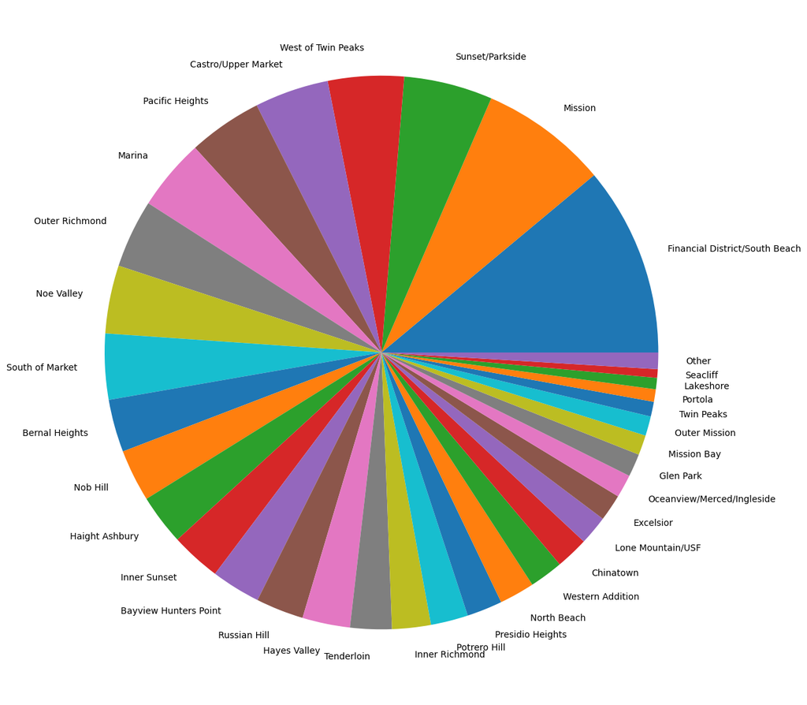

```python
nhoods = permits['Neighborhoods'].value_counts()
otherval = nhoods[nhoods <= 900].sum()
nhoods = nhoods[nhoods > 900].dropna()
nhoods["Other"] = otherval

plt.figure(figsize=(14, 14))
plt.pie(nhoods, labels=nhoods.keys())
plt.show()
```

It's important to understand what permits are attempting to modify——high-density housing, retail spaces, etc. Unfortunately, not all permits have information about how the land is being used. Are there a significant number of N/A rows in the "Existing Use" column? Print the percentage value using Pandas.

```python
existr = permits["Existing Use"].shape
na_vals = permits["Existing Use"].isna().sum()

print(f'{na_vals/existr[0] * 100}% of the Existing Use column is N/A.')
```

```
20.67068878833585% of the Existing Use column is N/A.
```

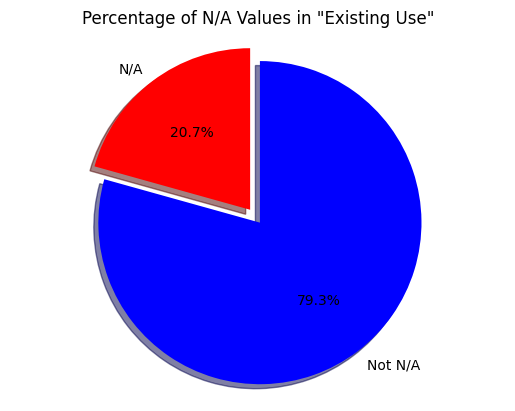

```python
# Calculate the percentage of N/A values in the "Existing Use" column
na_percentage = (na_vals / len(permits)) * 100

# Create a pie chart
labels = ['N/A', 'Not N/A']
sizes = [na_percentage, 100 - na_percentage]
colors = ['red','blue']
explode = (0.1, 0)

# Plot
plt.pie(sizes, explode=explode, labels=labels, colors=colors, autopct='%1.1f%%', shadow=True, startangle=90)
plt.title('Percentage of N/A Values in "Existing Use"')
plt.axis('equal')  # Equal aspect ratio ensures that pie is drawn as a circle.
plt.show()
```

In some cases, dropping N/A columns is important. But is an exception, as many building permits are for unutilized land. We should keep the N/A column, and we'll work with it later to prepare this data column for machine learning.

Now, let's explore if there is a correlation between the existing use of a building and the permit's completion status.

```python
corr = pd.crosstab(permits["Existing Use"], permits["Current Status"])

chi2, p, dof, expected = scipy.stats.chi2_contingency(corr)

# Computer Cramer's V
n = corr.sum().sum()
phi2 = chi2 / n
r, k = corr.shape
cramers_v = np.sqrt(phi2 / min(k-1, r-1))

print(f'Cramer\'s V: {cramers_v}')
```

```
Cramer's V: 0.04238999456003759
```

Let's remove "Current Status" now. The model won't need it.

```python
permits.drop(columns=["Current Status"])
```

|  | Permit Number | Permit Type Definition | Permit Creation Date | Completed Date | Existing Use | Neighborhoods | Proposed Use |
| --- | --- | --- | --- | --- | --- | --- | --- |
| 0 | 201505065519 | sign - erect | 05/06/2015 | NaN | tourist hotel/motel | Tenderloin | NaN |
| 1 | 201604195146 | sign - erect | 04/19/2016 | NaN | tourist hotel/motel | Tenderloin | NaN |
| 2 | 201605278609 | additions alterations or repairs | 05/27/2016 | NaN | retail sales | Russian Hill | retail sales |
| 3 | 201611072166 | otc alterations permit | 11/07/2016 | 07/24/2017 | 1 family dwelling | Nob Hill | 1 family dwelling |
| 4 | 201611283529 | demolitions | 11/28/2016 | NaN | retail sales | Tenderloin | NaN |
| ... | ... | ... | ... | ... | ... | ... | ... |
| 198895 | M862628 | otc alterations permit | 12/05/2017 | NaN | NaN | NaN | NaN |
| 198896 | 201712055595 | otc alterations permit | 12/05/2017 | NaN | apartments | NaN | apartments |
| 198897 | M863507 | otc alterations permit | 12/06/2017 | NaN | NaN | NaN | NaN |
| 198898 | M863747 | otc alterations permit | 12/06/2017 | NaN | NaN | NaN | NaN |
| 198899 | M864287 | otc alterations permit | 12/07/2017 | NaN | NaN | NaN | NaN |

198900 rows × 7 columns

From this value, we understand that there is little to no correlation between a building's existing use and the completion status of the permit.

Different neighborhoods might have different rates of permit completion; for instance, it's possible that wealthier neighborhoods have more completed permits. For each neighborhood, print the percentage of permits marked "completed."

```python
# Function to generate shades of a given color
def generate_shades(base_color, num_shades):
    base_color_rgb = np.array(mcolors.to_rgb(base_color))
    shades = [tuple(base_color_rgb * (1 - 0.5 * i / num_shades)) for i in range(num_shades)]
    return shades
```

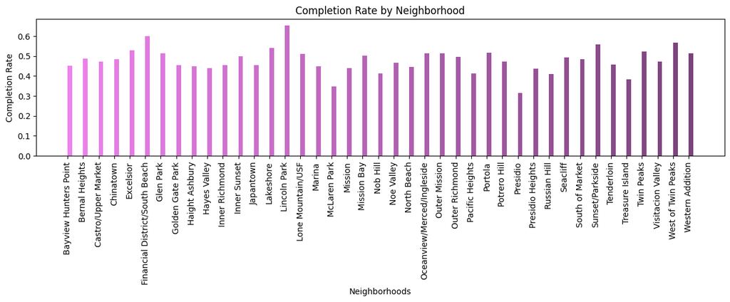

```python
total_permits_per_neighborhood = permits.groupby('Neighborhoods').count()['Permit Number']
completed_permits_per_neighborhood = permits.groupby('Neighborhoods').count()['Completed Date']

permits_df = pd.DataFrame({'Total Permits': total_permits_per_neighborhood, 'Completed Permits': completed_permits_per_neighborhood})
permits_df['Completion Rate'] = permits_df['Completed Permits'] / permits_df['Total Permits']

# Generate shades of purple
purple_shades = generate_shades('violet', len(permits_df))

plt.figure(figsize=(15, 3))  # width:20, height:3
plt.bar(range(len(permits_df)), permits_df['Completion Rate'], align='edge', width=0.3, color=purple_shades)
plt.xticks(range(len(permits_df)), permits_df.index, rotation='vertical')
plt.xlabel('Neighborhoods')
plt.ylabel('Completion Rate')
plt.title('Completion Rate by Neighborhood')
plt.show()
```

The above graph isn't enough to determine a correlation. Let's test if there's a correlation between neighborhood and completion rate using a hypothesis test.

H0: Neighborhood doesn't affect the permit completion rate.

Ha: Neighborhood does affect the permit completion rate.

Print the p-value and determine if it's enough to reject the null hypothesis. Let alpha = 0.05.

```python
hypoth_data = pd.crosstab(permits_df["Completion Rate"], permits_df.index)

scipy.stats.chi2_contingency(hypoth_data).pvalue
```

```
0.2379043771131508
```

Since our p-value is above the alpha value, we do not have sufficient evidence to reject the null hypothesis, and therefore we fail to reject it. From this, we can conclude that the neighborhood a permit is in does not affect whether or not it is completed.

Finally, let's see if there are any outliers for "Proposed Use." Some types of building proposals may be very rare or unusual, so they might be underrepresented in public data. Outliers could affect the model's performance on rare permit types, since it has little information to learn from in the first place. Print the value_counts for this column.

```python
proposed_uses = permits["Proposed Use"].value_counts()

proposed_uses
```

| Proposed Use | count |
| --- | --- |
| 1 family dwelling | 46346 |
| apartments | 43032 |
| office | 23962 |
| 2 family dwelling | 22061 |
| retail sales | 5079 |
| ... | ... |
| temple | 2 |
| dairies/dairy equip. | 1 |
| roofing materials | 1 |
| orphanage | 1 |
| not applicable | 1 |

94 rows × 1 columns

**dtype:** int64

From this output it's clear that there are some outliers. There was one dairy equipment permit in the dataset——a rare construction proposal for one of the largest cities in the country!

```python
proposed_uses_to_remove = proposed_uses[proposed_uses < 30].index # The series values are counts, the labels/index array is the uses as strings

permits = permits[~permits["Proposed Use"].isin(proposed_uses_to_remove)] # Keep if Proposed Use value is NOT in proposed_uses_to_remove

permits["Proposed Use"].value_counts()

permits.head()
```

|  | Permit Number | Permit Type Definition | Permit Creation Date | Current Status | Completed Date | Existing Use | Neighborhoods | Proposed Use |
| --- | --- | --- | --- | --- | --- | --- | --- | --- |
| 0 | 201505065519 | sign - erect | 05/06/2015 | expired | NaN | tourist hotel/motel | Tenderloin | NaN |
| 1 | 201604195146 | sign - erect | 04/19/2016 | issued | NaN | tourist hotel/motel | Tenderloin | NaN |
| 2 | 201605278609 | additions alterations or repairs | 05/27/2016 | withdrawn | NaN | retail sales | Russian Hill | retail sales |
| 3 | 201611072166 | otc alterations permit | 11/07/2016 | complete | 07/24/2017 | 1 family dwelling | Nob Hill | 1 family dwelling |
| 4 | 201611283529 | demolitions | 11/28/2016 | issued | NaN | retail sales | Tenderloin | NaN |

```python
definitions = permits['Permit Type Definition'].value_counts()

definitions
```

| Permit Type Definition | count |
| --- | --- |
| otc alterations permit | 178531 |
| additions alterations or repairs | 14585 |
| sign - erect | 2892 |
| new construction wood frame | 941 |
| demolitions | 600 |
| wall or painted sign | 511 |
| new construction | 342 |
| grade or quarry or fill or excavate | 91 |

**dtype:** int64

```python
to_remove = definitions[definitions < 550].index

permits = permits[~permits["Permit Type Definition"].isin(to_remove)] # Keep if Proposed Use value is NOT in proposed_uses_to_remove

permits["Permit Type Definition"].value_counts()

permits.head()
```

|  | Permit Number | Permit Type Definition | Permit Creation Date | Current Status | Completed Date | Existing Use | Neighborhoods | Proposed Use |
| --- | --- | --- | --- | --- | --- | --- | --- | --- |
| 0 | 201505065519 | sign - erect | 05/06/2015 | expired | NaN | tourist hotel/motel | Tenderloin | NaN |
| 1 | 201604195146 | sign - erect | 04/19/2016 | issued | NaN | tourist hotel/motel | Tenderloin | NaN |
| 2 | 201605278609 | additions alterations or repairs | 05/27/2016 | withdrawn | NaN | retail sales | Russian Hill | retail sales |
| 3 | 201611072166 | otc alterations permit | 11/07/2016 | complete | 07/24/2017 | 1 family dwelling | Nob Hill | 1 family dwelling |
| 4 | 201611283529 | demolitions | 11/28/2016 | issued | NaN | retail sales | Tenderloin | NaN |

# Primary Analysis & Developing the model

We want to determine how various independent factors we've cherry-picked in previous sections will impact the likelihood of a permit being approved. The neighborhood or existing use of land, for instance, could potentially impact the probability.

The independent factors that the model will be trained on are called **features**.

Many features are categorical, meaning they fall into discrete categories (as opposed to something like continuous numerical data), and the categories are strings.

Models might learn from the characters in these strings instead of the actual underlying data they're intended to represent. To address this issue, categorical data must be converted into discrete binary columns in a process called **One-Hot Encoding**.

If you've never learned about One-Hot Encoding before, check out this well-written [article](https://www.geeksforgeeks.org/ml-one-hot-encoding/).

Use sklearn's `OneHotEncoder` to encode the categorical variables, which are all the features except the creation date, since time is continuous.

Why are zip codes categorical? While these numbers may be continuous, an increase or decrease in zip codes doesn't reveal anything about the neighborhood; a zip code is essentially a neighborhood described by a number, just like how neighboroods are described by strings/words in everyday life.

```python
from sklearn.preprocessing import OneHotEncoder
import numpy as np
```

```python
encoder = OneHotEncoder(sparse_output=False)

relevant_columns = ["Permit Type Definition", "Existing Use", "Neighborhoods", "Proposed Use"]

# Encode the data using fit_transform
encoded_columns = encoder.fit_transform(permits[relevant_columns])

permits = permits.drop(columns=relevant_columns) # Drop old categorical columns for one-hot encoding
permits = permits.drop(columns=["Current Status"])

encoded_df = pd.DataFrame(encoded_columns, columns=encoder.get_feature_names_out(relevant_columns))

permits = permits.reset_index(drop=True)
encoded_df = encoded_df.reset_index(drop=True)

permits = pd.concat([permits, encoded_df], axis=1) # Merge one-hot encoding with other data

permits.head() # To see the new data
```

|  | Permit Number | Permit Creation Date | Completed Date | Permit Type Definition_additions alterations or repairs | Permit Type Definition_demolitions | Permit Type Definition_new construction wood frame | Permit Type Definition_otc alterations permit | Permit Type Definition_sign - erect | Existing Use_1 family dwelling | Existing Use_2 family dwelling | ... | Proposed Use_social care facility | Proposed Use_storage shed | Proposed Use_theater | Proposed Use_tourist hotel/motel | Proposed Use_vacant lot | Proposed Use_warehouse, furniture | Proposed Use_warehouse,no frnitur | Proposed Use_wholesale sales | Proposed Use_workshop commercial | Proposed Use_nan |
| --- | --- | --- | --- | --- | --- | --- | --- | --- | --- | --- | --- | --- | --- | --- | --- | --- | --- | --- | --- | --- | --- |
| 0 | 201505065519 | 05/06/2015 | NaN | 0.0 | 0.0 | 0.0 | 0.0 | 1.0 | 0.0 | 0.0 | ... | 0.0 | 0.0 | 0.0 | 0.0 | 0.0 | 0.0 | 0.0 | 0.0 | 0.0 | 1.0 |
| 1 | 201604195146 | 04/19/2016 | NaN | 0.0 | 0.0 | 0.0 | 0.0 | 1.0 | 0.0 | 0.0 | ... | 0.0 | 0.0 | 0.0 | 0.0 | 0.0 | 0.0 | 0.0 | 0.0 | 0.0 | 1.0 |
| 2 | 201605278609 | 05/27/2016 | NaN | 1.0 | 0.0 | 0.0 | 0.0 | 0.0 | 0.0 | 0.0 | ... | 0.0 | 0.0 | 0.0 | 0.0 | 0.0 | 0.0 | 0.0 | 0.0 | 0.0 | 0.0 |
| 3 | 201611072166 | 11/07/2016 | 07/24/2017 | 0.0 | 0.0 | 0.0 | 1.0 | 0.0 | 1.0 | 0.0 | ... | 0.0 | 0.0 | 0.0 | 0.0 | 0.0 | 0.0 | 0.0 | 0.0 | 0.0 | 0.0 |
| 4 | 201611283529 | 11/28/2016 | NaN | 0.0 | 1.0 | 0.0 | 0.0 | 0.0 | 0.0 | 0.0 | ... | 0.0 | 0.0 | 0.0 | 0.0 | 0.0 | 0.0 | 0.0 | 0.0 | 0.0 | 1.0 |

5 rows × 181 columns

Now that the categorical data is in a format that works better for machine learning models, we'll need to fix the "Permit Creation Date" column. Dates formatted as MM/DD/YYYY are strings, so like the categorical variables we just encoded, the machine learning model shouldn't be trained with this data.

Dates are not categorical though—a higher date (converted into a continous number like months or days) signifies a later point in time, and an increase or decrease in the number means something. However, day might be less relevant; based on how permits approvals work in the U.S., we can safely say the day relative to the start of a month is unlikely to really impact what happens to the permit.

Convert this column into a column of two integer columns, "Permit Creation Month" and "Permit Creation Year." Be sure to remove the original column once you're finished.

For help: https://pandas.pydata.org/docs/reference/api/pandas.Series.dt.year.html and https://pandas.pydata.org/docs/reference/api/pandas.Series.dt.month.html

```python
# Convert the column into a datetime data format first
permits["Permit Creation Date"] = pd.to_datetime(permits['Permit Creation Date'], format='%m/%d/%Y')

permits["Permit Creation Month"] = permits["Permit Creation Date"].dt.month
permits["Permit Creation Year"] = permits["Permit Creation Date"].dt.year

permits = permits.drop(columns=["Permit Creation Date"])

permits.head()
```

|  | Permit Number | Completed Date | Permit Type Definition_additions alterations or repairs | Permit Type Definition_demolitions | Permit Type Definition_new construction wood frame | Permit Type Definition_otc alterations permit | Permit Type Definition_sign - erect | Existing Use_1 family dwelling | Existing Use_2 family dwelling | Existing Use_accessory cottage | ... | Proposed Use_theater | Proposed Use_tourist hotel/motel | Proposed Use_vacant lot | Proposed Use_warehouse, furniture | Proposed Use_warehouse,no frnitur | Proposed Use_wholesale sales | Proposed Use_workshop commercial | Proposed Use_nan | Permit Creation Month | Permit Creation Year |
| --- | --- | --- | --- | --- | --- | --- | --- | --- | --- | --- | --- | --- | --- | --- | --- | --- | --- | --- | --- | --- | --- |
| 0 | 201505065519 | NaN | 0.0 | 0.0 | 0.0 | 0.0 | 1.0 | 0.0 | 0.0 | 0.0 | ... | 0.0 | 0.0 | 0.0 | 0.0 | 0.0 | 0.0 | 0.0 | 1.0 | 5 | 2015 |
| 1 | 201604195146 | NaN | 0.0 | 0.0 | 0.0 | 0.0 | 1.0 | 0.0 | 0.0 | 0.0 | ... | 0.0 | 0.0 | 0.0 | 0.0 | 0.0 | 0.0 | 0.0 | 1.0 | 4 | 2016 |
| 2 | 201605278609 | NaN | 1.0 | 0.0 | 0.0 | 0.0 | 0.0 | 0.0 | 0.0 | 0.0 | ... | 0.0 | 0.0 | 0.0 | 0.0 | 0.0 | 0.0 | 0.0 | 0.0 | 5 | 2016 |
| 3 | 201611072166 | 07/24/2017 | 0.0 | 0.0 | 0.0 | 1.0 | 0.0 | 1.0 | 0.0 | 0.0 | ... | 0.0 | 0.0 | 0.0 | 0.0 | 0.0 | 0.0 | 0.0 | 0.0 | 11 | 2016 |
| 4 | 201611283529 | NaN | 0.0 | 1.0 | 0.0 | 0.0 | 0.0 | 0.0 | 0.0 | 0.0 | ... | 0.0 | 0.0 | 0.0 | 0.0 | 0.0 | 0.0 | 0.0 | 1.0 | 11 | 2016 |

5 rows × 182 columns

Finally, the "Completed Date" column is important because it's the *result* of the independent variables. This is what needs to be classified. If the permit got completed, a date will exist, but otherwise it's NaN in the column.

Turn the NaN values into 0 and the values with dates into 1, and save that to a variable called Y, which will be the training labels.

Take everything else and save it to a variable called X, the training data input.

```python
y = ~(permits["Completed Date"].isna())

X = permits.drop(columns=["Completed Date"])

print(X.shape)
```

```
(197549, 181)
```

Let's also drop "Permit Number" since it doesn't relate to the permit approval status; they're randomly-generated identifiers for public ease-of-access.

```python
X = X.drop(columns=["Permit Number"])
```

Now let's split the data using `test_train_split()`. Set the random_state to 42 and make everything else default.

For information on this function: https://scikit-learn.org/dev/modules/generated/sklearn.model_selection.train_test_split.html

```python
X[X.isna().any(axis=1)]
```

|  | Permit Type Definition_additions alterations or repairs | Permit Type Definition_demolitions | Permit Type Definition_new construction wood frame | Permit Type Definition_otc alterations permit | Permit Type Definition_sign - erect | Existing Use_1 family dwelling | Existing Use_2 family dwelling | Existing Use_accessory cottage | Existing Use_adult entertainment | Existing Use_animal sale or care | ... | Proposed Use_theater | Proposed Use_tourist hotel/motel | Proposed Use_vacant lot | Proposed Use_warehouse, furniture | Proposed Use_warehouse,no frnitur | Proposed Use_wholesale sales | Proposed Use_workshop commercial | Proposed Use_nan | Permit Creation Month | Permit Creation Year |
| --- | --- | --- | --- | --- | --- | --- | --- | --- | --- | --- | --- | --- | --- | --- | --- | --- | --- | --- | --- | --- | --- |

0 rows × 180 columns

```python
from sklearn.model_selection import train_test_split

X_train, X_test, y_train, y_test = train_test_split(X, y, random_state=42)
```

```python
from sklearn.linear_model import LogisticRegression
from sklearn.metrics import accuracy_score
from sklearn.preprocessing import StandardScaler

scaler = StandardScaler()
X_train_scaled = scaler.fit_transform(X_train)
X_test_scaled = scaler.transform(X_test)

model = LogisticRegression(max_iter=500, random_state=42, class_weight='balanced')
model.fit(X_train_scaled, y_train)

# Make predictions on the test set
y_pred = model.predict(X_test_scaled)

# Evaluate the model using accuracy
accuracy = accuracy_score(y_test, y_pred)

accuracy
```

```
0.7541305580302907
```

This accuracy might be misleading. Oftentimes, machine learning models may perform well on specific test/train data splits, but not on others. K-Fold Validation creates different *folds*, each of which splits the data into different test/train groups, which can give a more holistic accuracy. Let's try K-Fold to double-check that our accuracy works as intended.

Confused? Check out this K-Fold Validation article: https://scikit-learn.org/1.5/modules/cross_validation.html

To implement this code sklearn's `KFold`: see https://scikit-learn.org/dev/modules/generated/sklearn.model_selection.KFold.html

```python
from sklearn.model_selection import cross_val_score
from sklearn.model_selection import KFold

model_fold = LogisticRegression(max_iter=500, random_state=42)

kfold = KFold(shuffle=True, random_state=42)

# Step 4: Evaluate using cross_val_score
scores = cross_val_score(model_fold, X, y, cv=kfold, scoring='accuracy')

# Step 5: Print the results
scores
```

[output not shown]

[output cut: 33 more lines]

[output not shown]

```python
# check feature importance
coeff = model.coef_[0]
odds_ratios = np.exp(coeff)

feature_importance_df = pd.DataFrame({'Feature' : X.columns, 'Coefficient': coeff, 'Odds Ratio': odds_ratios})
```

```python
feature_importance_df.sort_values(by='Coefficient', ascending=False).head(30)
```

|  | Feature | Coefficient | Odds Ratio |
| --- | --- | --- | --- |
| 124 | Proposed Use_1 family dwelling | 0.526693 | 1.693324 |
| 4 | Permit Type Definition_sign - erect | 0.509559 | 1.664557 |
| 128 | Proposed Use_apartments | 0.431371 | 1.539367 |
| 154 | Proposed Use_office | 0.384240 | 1.468498 |
| 125 | Proposed Use_2 family dwelling | 0.337162 | 1.400967 |
| 1 | Permit Type Definition_demolitions | 0.223844 | 1.250876 |
| 141 | Proposed Use_food/beverage hndlng | 0.173203 | 1.189108 |
| 131 | Proposed Use_automobile sales | 0.161653 | 1.175453 |
| 165 | Proposed Use_retail sales | 0.136101 | 1.145797 |
| 166 | Proposed Use_school | 0.105516 | 1.111284 |
| 171 | Proposed Use_tourist hotel/motel | 0.105386 | 1.111139 |
| 174 | Proposed Use_warehouse,no frnitur | 0.093757 | 1.098293 |
| 11 | Existing Use_apartments | 0.090844 | 1.095098 |
| 6 | Existing Use_2 family dwelling | 0.081101 | 1.084480 |
| 63 | Existing Use_residential hotel | 0.080243 | 1.083550 |
| 10 | Existing Use_antenna | 0.079486 | 1.082730 |
| 134 | Proposed Use_clinics-medic/dental | 0.073840 | 1.076635 |
| 170 | Proposed Use_theater | 0.062033 | 1.063997 |
| 87 | Neighborhoods_Financial District/South Beach | 0.061258 | 1.063173 |
| 67 | Existing Use_social care facility | 0.054674 | 1.056196 |
| 142 | Proposed Use_greenhouse | 0.050076 | 1.051351 |
| 38 | Existing Use_library | 0.050061 | 1.051335 |
| 132 | Proposed Use_barber/beauty salon | 0.049741 | 1.050999 |
| 143 | Proposed Use_health studios & gym | 0.049626 | 1.050878 |
| 148 | Proposed Use_manufacturing | 0.049331 | 1.050568 |
| 152 | Proposed Use_museum | 0.048064 | 1.049238 |
| 146 | Proposed Use_lending institution | 0.046325 | 1.047415 |
| 42 | Existing Use_misc group residns. | 0.044084 | 1.045070 |
| 129 | Proposed Use_artist live/work | 0.043725 | 1.044695 |
| 176 | Proposed Use_workshop commercial | 0.043194 | 1.044141 |

```python
feature_importance_df.sort_values(by='Coefficient', ascending=True).head(30)
```

|  | Feature | Coefficient | Odds Ratio |
| --- | --- | --- | --- |
| 177 | Proposed Use_nan | -1.803839 | 0.164666 |
| 179 | Permit Creation Year | -0.594133 | 0.552041 |
| 0 | Permit Type Definition_additions alterations o... | -0.300539 | 0.740419 |
| 81 | Existing Use_nan | -0.177729 | 0.837169 |
| 14 | Existing Use_automobile sales | -0.167065 | 0.846145 |
| 178 | Permit Creation Month | -0.132410 | 0.875982 |
| 2 | Permit Type Definition_new construction wood f... | -0.067701 | 0.934540 |
| 127 | Proposed Use_antenna | -0.046432 | 0.954630 |
| 147 | Proposed Use_library | -0.040796 | 0.960025 |
| 7 | Existing Use_accessory cottage | -0.039473 | 0.961296 |
| 44 | Existing Use_moving & storage | -0.033810 | 0.966755 |
| 65 | Existing Use_school | -0.032924 | 0.967612 |
| 16 | Existing Use_building materials | -0.032674 | 0.967854 |
| 168 | Proposed Use_social care facility | -0.031993 | 0.968513 |
| 33 | Existing Use_greenhouse | -0.028433 | 0.971967 |
| 48 | Existing Use_nite club | -0.027902 | 0.972483 |
| 120 | Neighborhoods_Visitacion Valley | -0.027035 | 0.973327 |
| 113 | Neighborhoods_Russian Hill | -0.026218 | 0.974122 |
| 82 | Neighborhoods_Bayview Hunters Point | -0.025300 | 0.975018 |
| 27 | Existing Use_day care home lt 7 | -0.024809 | 0.975496 |
| 72 | Existing Use_swimming pool | -0.024690 | 0.975612 |
| 69 | Existing Use_stadium | -0.024466 | 0.975831 |
| 73 | Existing Use_theater | -0.024326 | 0.975967 |
| 100 | Neighborhoods_Mission | -0.024265 | 0.976027 |
| 85 | Neighborhoods_Chinatown | -0.023409 | 0.976863 |
| 59 | Existing Use_prson'l svc tutor | -0.023040 | 0.977223 |
| 76 | Existing Use_vacant lot | -0.022880 | 0.977380 |
| 117 | Neighborhoods_Tenderloin | -0.022793 | 0.977465 |
| 102 | Neighborhoods_Nob Hill | -0.020799 | 0.979416 |
| 79 | Existing Use_wholesale sales | -0.019927 | 0.980270 |

## Visualizations

What did the original model most rely on make predictions? Let's use the coefficients applied to the features to see.

Need a hint? Check out the `coef_` attribute at this page: https://scikit-learn.org/1.5/modules/generated/sklearn.linear_model.LinearRegression.html

```python
# get the models coefficient list and create a dataframe
coeff = model.coef_[0]
feature_importance_df = pd.DataFrame({'Feature' : X.columns, 'Coefficient': coeff})

# extract top 10 features for visualization
important_features = feature_importance_df.sort_values(by='Coefficient', ascending=False).head(10)
```

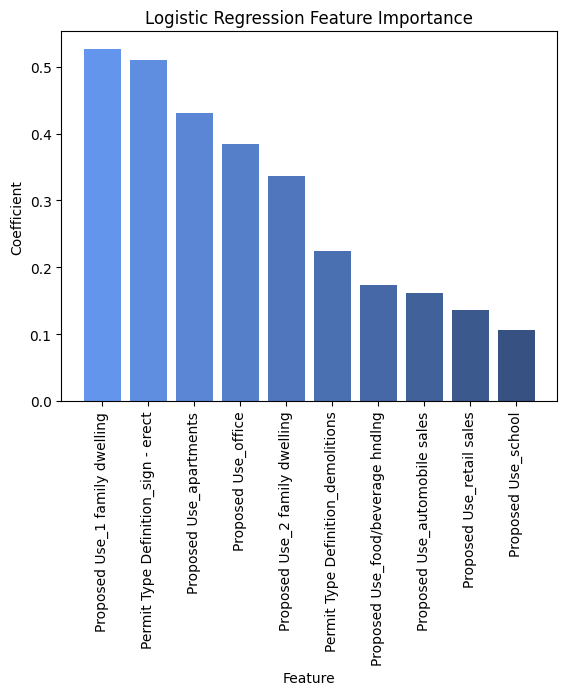

```python
# create bar plot
plt.bar(important_features['Feature'], important_features['Coefficient'], color=generate_shades('cornflowerblue', 10))
plt.xticks(range(len(important_features)), important_features['Feature'], rotation='vertical')
plt.xlabel('Feature')
plt.ylabel('Coefficient')
plt.title('Logistic Regression Feature Importance')
```

These are positive coefficients, so they have a positive relationship with a permit completion.

What about features that had a negative relationship with the completion of a permit?

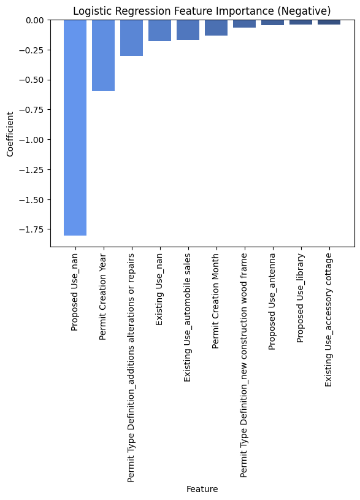

```python
# get the models coefficient list and create a dataframe
coeff = model.coef_[0]
feature_importance_df = pd.DataFrame({'Feature' : X.columns, 'Coefficient': coeff})

# extract top 10 features for visualization
important_features = feature_importance_df.sort_values(by='Coefficient', ascending=True).head(10)

# create bar plot
plt.bar(important_features['Feature'], important_features['Coefficient'], color=generate_shades('cornflowerblue', 10))
plt.xticks(range(len(important_features)), important_features['Feature'], rotation='vertical')
plt.xlabel('Feature')
plt.ylabel('Coefficient')
plt.title('Logistic Regression Feature Importance (Negative)')
```

Finally, let's visualize the machine learning model's (the original one, anyway) confusion matrix. Confusion matrices give us information about a model's performance, including accuracy.

If you've never interacted with a confusion matrix before, check out a quick briefer: https://www.geeksforgeeks.org/confusion-matrix-machine-learning/

[figure not shown]

```python
from sklearn.metrics import ConfusionMatrixDisplay
from sklearn.metrics import confusion_matrix

# Create confusion matrix of True Positives, True Negatives, False Positives, and False Negatives
cfm = confusion_matrix(y_test, y_pred)

# Use sklearn's ConfusionMatrixDisplay() function to create a visualization
cfm_display = ConfusionMatrixDisplay(cfm, display_labels=['Completed', 'Not Completed'])

# Set colormap so green signifies a correct prediction and red signifies and incorrect prediction
cfm_display.plot(cmap=plt.cm.RdYlGn)

# Add title
cfm_display.ax_.set_title('Confusion Matrix')

plt.show()
```

# Insights and Conclusions

The positive coefficients reveal some insights. Signs are likely to lead to a completed permit; a sensible outcome, as signs are quick to install and are unlikely to receive much of San Francisco's notorious NIMBY opposition.

Permits for single family homes, offices, retail spaces, and apartments are also likely to be completed. These are all common construction projects in big cities, and despite the housing shortage, it doesn't seem like housing is less likely to be constructed compared to other projects. In fact, the opposite is true! The [San Francisco Standard](https://sfstandard.com/2023/12/22/san-francisco-record-low-housing-permits-despite-shortage/) reported that housing projects were completed in an increasing amount during the years represented in the dataset. So, housing is being completed, just not at the pace necessary to meet demand. Other factors like construction costs or tax policies might be discouraging permits from being submitted in the first place, which our data can't demonstrate.

From the negative coefficients we see that a missing Proposed Use in the permit severely impacts the completion status; this would make sense, as a permit that doesn't contain any informatin about its Proposed Use is unlikely to be approved and moved onto later stages.

What else? Note that land being used for automobile sales has a negative relationship with completion. San Francisco has been trending towards [reduced car ownership](https://www.corporateknights.com/built-environment/car-free-san-francisco/) for a while, but has struggled for many years to [reduce the amount of space car-related infrastructure takes up](https://thefrisc.com/sfs-cars-to-casas-law-highlights-deep-housing-rifts-even-with-unanimous-support-47d3fc4fa775/). It would make sense that these automobile-related permits are less likely to reach a completed state as these may receive a lot of opposition from existing land owners or city residents unwilling to give up their cars.

The confusion matrix, and the accuracies from earlier, suggest that a good amount of test examples weren't classified correctly.

There could be many causes for this; most likely, it's possible that there isn't a strong relationship between many permit properties and the likelihood that the proposal will be completed. We saw earlier that completion rate **was not** impacted by neighborhood——this is a huge factor in how housing gets constructed, as wealthier neighborhoods are known to [oppose housing construction at higher rates](https://sf.curbed.com/2020/2/20/21122662/san-francisco-bay-area-nimbys-history-nimby-development).